# Using `stringr` to Work with Strings

## Monday, Febrary 3

Today we will…

- Different schedule this week
- What you can expect in Week 6
- New material
  - String variables
  - Functions for working with strings
  - Regular expressions
- PA 5.1: Scrambled Message

## Week 5 Layout

- Today: Strings with `stringr`
  - Practice Activity: Decoding a Message
- Wednesday: Dates with `lubridate`
  - Practice Activity: Jewel Heist
  - Discuss midterm exam and project
- Lab Assignment Solving a Murder Mystery
  - Using `dplyr` + `stringr` + `ludridate`

## Week 6 Layout

- Monday: Version control with `git`
  - Practice Activity
- Wednesday: Midterm Exam

## Comments from Week 4

**Read**

Average

Total

Which or For Each

Minimum

Maximum

**Think**

`summarize(avg = mean())`

`summarize(total = sum())`

`group_by()`

`slice_min()`

`slice_max()`

# String Variables

## What is a string?

A **string** is a bunch of **characters**.

There is a difference between…

…a **string** (many characters, one object)…

and

…a **character vector** (vector of strings).

```r
my_string <- "Hi, my name is Bond!"
my_string
```

```
[1] "Hi, my name is Bond!"
```

```r
my_vector <- c("Hi", "my", "name", "is", "Bond")
my_vector
```

```
[1] "Hi"   "my"   "name" "is"   "Bond"
```

## `stringr`

**Common tasks**

- Identify strings containing a particular pattern.
- Remove or replace a pattern.
- Edit a string (e.g., make it lowercase).

[figure not shown]

**Note**

- The `stringr` package loads with `tidyverse`.
- All functions are of the form `str_xxx()`.

## `pattern =`

The `pattern` **argument** appears in many `stringr` functions.

- The pattern **must** be supplied inside quotes.

```r
my_vector <- c("Hello,",
               "my name is",
               "Bond",
               "James Bond")

str_detect(my_vector, pattern = "Bond")
str_locate(my_vector, pattern = "James Bond")
str_match(my_vector, pattern = "[bB]ond")
str_extract(my_vector, pattern = "[jJ]ames [bB]ond")
```

Let’s explore these functions!

## `str_detect()`

Returns a **logical vector** indicating whether the pattern was found in each element of the supplied vector.

```r
my_vector <- c("Hello,",
               "my name is",
               "Bond",
               "James Bond")
str_detect(my_vector, pattern = "Bond")
```

```
[1] FALSE FALSE  TRUE  TRUE
```

- Pairs well with `filter()`.
- Works with `summarise()` + `sum` (to get total matches) or `mean` (to get proportion of matches).

**Related Function**

`str_which()` returns the indexes of the strings that contain a match.

## `str_match()`

Returns a **character matrix** containing either `NA` or the pattern, depending on if the pattern was found.

```r
my_vector <- c("Hello,",
               "my name is",
               "Bond",
               "James Bond")

str_match(my_vector, pattern = "Bond")
```

```
     [,1]
[1,] NA
[2,] NA
[3,] "Bond"
[4,] "Bond"
```

## `str_extract()`

Returns a **character vector** with either `NA` or the pattern, depending on if the pattern was found.

```r
my_vector <- c("Hello,",
               "my name is",
               "Bond",
               "James Bond")

str_extract(my_vector, pattern = "Bond")
```

```
[1] NA     NA     "Bond" "Bond"
```

**Warning**

`str_extract()` only returns the **first** pattern match.

Use `str_extract_all()` to return **every** pattern match.

## What do you mean by the *first* match?

Suppose we had a slightly different vector…

```r
alt_vector <- c("Hello,",
               "my name is",
               "Bond, James Bond")
```

If we were to extract *every* instance of `"Bond"` from the vector…

```r
str_extract(alt_vector,
            pattern = "Bond")
```

```
[1] NA     NA     "Bond"
```

```r
str_extract_all(alt_vector,
                pattern = "Bond")
```

```
[[1]]
character(0)

[[2]]
character(0)

[[3]]
[1] "Bond" "Bond"
```

## `str_locate()`

```r
my_vector <- c("Hello,",
               "my name is",
               "Bond",
               "James Bond")

str_locate(my_vector, pattern = "Bond")
```

```
     start end
[1,]    NA  NA
[2,]    NA  NA
[3,]     1   4
[4,]     7  10
```

**Related Function**

`str_sub()` extracts values based on a starting and ending location.

## `str_subset()`

Returns a **character vector** containing a subset of the original **character vector** consisting of the elements where the pattern was found *anywhere in the element*.

```r
my_vector <- c("Hello,",
               "my name is",
               "Bond",
               "James Bond")

str_subset(my_vector, pattern = "Bond")
```

```
[1] "Bond"       "James Bond"
```

## Try it out!

```r
my_vector <- c("I scream,",
               "you scream",
               "we all",
               "scream",
               "for",
               "ice cream")

str_detect(my_vector, pattern = "cream")
str_locate(my_vector, pattern = "cream")
str_match(my_vector, pattern = "cream")
str_extract(my_vector, pattern = "cream")
str_subset(my_vector, pattern = "cream")
```

**Note**

For each of these functions, write down:

- the **object structure** of the output.
- the **data type** of the output.
- a brief explanation of what they do.

## Replace / Remove Patterns

- `str_replace()`
- `str_remove()`

Replace the **first** matched pattern in each string.

- Pairs well with `mutate()`.

```r
str_replace(my_vector,
            pattern = "Bond",
            replace = "Franco")
```

```
[1] "Hello,"       "my name is"   "Franco"       "James Franco"
```

**Related Function**

`str_replace_all()` replaces **all** matched patterns in each string.

Remove the **first** matched pattern in each string.

```r
str_remove(my_vector,
           pattern = "Bond")
```

```
[1] "Hello,"     "my name is" ""           "James "
```

**Related Functions**

This is a special case of `str_replace(x, pattern, replacement = "")`.

`str_remove_all()` removes **all** matched patterns in each string.

## Edit Strings

Convert letters in a string to a specific capitalization format.

- lower
- UPPER
- Title

`str_to_lower()` converts all letters in a string to lowercase.

```r
str_to_lower(my_vector)
```

```
[1] "hello,"     "my name is" "bond"       "james bond"
```

`str_to_upper()` converts all letters in a string to uppercase.

```r
str_to_upper(my_vector)
```

```
[1] "HELLO,"     "MY NAME IS" "BOND"       "JAMES BOND"
```

`str_to_title()` converts the first letter of each word to uppercase.

```r
str_to_title(my_vector)
```

```
[1] "Hello,"     "My Name Is" "Bond"       "James Bond"
```

**This is handy for axis labels!**

## Combine Strings

- `str_c()`
- `str_flatten()`
- `str_glue()`

Join multiple strings into a single character vector.

```r
prompt <- "Hello, my name is"
first  <- "James"
last   <- "Bond"
str_c(prompt, last, ",", first, last, sep = " ")
```

```
[1] "Hello, my name is Bond , James Bond"
```

**Note**

Similar to `paste()` and `paste0()`.

Combine a vector of strings into a single string.

```r
my_vector <- c("Hello,",
               "my name is",
               "Bond",
               "James Bond")

str_flatten(my_vector, collapse = " ")
```

```
[1] "Hello, my name is Bond James Bond"
```

Use variables in the environment to create a string based on {expressions}.

```r
first <- "James"
last <- "Bond"
str_glue("My name is {last}, {first} {last}")
```

```
My name is Bond, James Bond
```

**Tip**

For more details, I would recommend looking up the [`glue` R package](https://glue.tidyverse.org/)!

## Tips for String Success

- Refer to the [`stringr` cheatsheet](https://posit.co/wp-content/uploads/2022/10/strings-1.pdf)
- Remember that `str_xxx` functions need the first argument to be a **vector of strings**, not a **dataset**!
  - You will use these functions *inside* `dplyr` verbs like `filter()` or `mutate()`.

```r
cereal |>
  mutate(is_bran = str_detect(name, "Bran"),
         .after = name)
```

| name | is_bran | manuf | type | calories | protein | fat | sodium | fiber | carbo | sugars | potass | vitamins | shelf | weight | cups | rating |
| --- | --- | --- | --- | --- | --- | --- | --- | --- | --- | --- | --- | --- | --- | --- | --- | --- |
| 100% Bran | TRUE | N | cold | 70 | 4 | 1 | 130 | 10.0 | 5.0 | 6 | 280 | 25 | 3 | 1.00 | 0.33 | 68.40297 |
| 100% Natural Bran | TRUE | Q | cold | 120 | 3 | 5 | 15 | 2.0 | 8.0 | 8 | 135 | 0 | 3 | 1.00 | 1.00 | 33.98368 |
| All-Bran | TRUE | K | cold | 70 | 4 | 1 | 260 | 9.0 | 7.0 | 5 | 320 | 25 | 3 | 1.00 | 0.33 | 59.42551 |
| All-Bran with Extra Fiber | TRUE | K | cold | 50 | 4 | 0 | 140 | 14.0 | 8.0 | 0 | 330 | 25 | 3 | 1.00 | 0.50 | 93.70491 |
| Almond Delight | FALSE | R | cold | 110 | 2 | 2 | 200 | 1.0 | 14.0 | 8 | -1 | 25 | 3 | 1.00 | 0.75 | 34.38484 |
| Apple Cinnamon Cheerios | FALSE | G | cold | 110 | 2 | 2 | 180 | 1.5 | 10.5 | 10 | 70 | 25 | 1 | 1.00 | 0.75 | 29.50954 |
| Apple Jacks | FALSE | K | cold | 110 | 2 | 0 | 125 | 1.0 | 11.0 | 14 | 30 | 25 | 2 | 1.00 | 1.00 | 33.17409 |
| Basic 4 | FALSE | G | cold | 130 | 3 | 2 | 210 | 2.0 | 18.0 | 8 | 100 | 25 | 3 | 1.33 | 0.75 | 37.03856 |
| Bran Chex | TRUE | R | cold | 90 | 2 | 1 | 200 | 4.0 | 15.0 | 6 | 125 | 25 | 1 | 1.00 | 0.67 | 49.12025 |
| Bran Flakes | TRUE | P | cold | 90 | 3 | 0 | 210 | 5.0 | 13.0 | 5 | 190 | 25 | 3 | 1.00 | 0.67 | 53.31381 |
| Cap'n'Crunch | FALSE | Q | cold | 120 | 1 | 2 | 220 | 0.0 | 12.0 | 12 | 35 | 25 | 2 | 1.00 | 0.75 | 18.04285 |
| Cheerios | FALSE | G | cold | 110 | 6 | 2 | 290 | 2.0 | 17.0 | 1 | 105 | 25 | 1 | 1.00 | 1.25 | 50.76500 |
| Cinnamon Toast Crunch | FALSE | G | cold | 120 | 1 | 3 | 210 | 0.0 | 13.0 | 9 | 45 | 25 | 2 | 1.00 | 0.75 | 19.82357 |
| Clusters | FALSE | G | cold | 110 | 3 | 2 | 140 | 2.0 | 13.0 | 7 | 105 | 25 | 3 | 1.00 | 0.50 | 40.40021 |
| Cocoa Puffs | FALSE | G | cold | 110 | 1 | 1 | 180 | 0.0 | 12.0 | 13 | 55 | 25 | 2 | 1.00 | 1.00 | 22.73645 |
| Corn Chex | FALSE | R | cold | 110 | 2 | 0 | 280 | 0.0 | 22.0 | 3 | 25 | 25 | 1 | 1.00 | 1.00 | 41.44502 |
| Corn Flakes | FALSE | K | cold | 100 | 2 | 0 | 290 | 1.0 | 21.0 | 2 | 35 | 25 | 1 | 1.00 | 1.00 | 45.86332 |
| Corn Pops | FALSE | K | cold | 110 | 1 | 0 | 90 | 1.0 | 13.0 | 12 | 20 | 25 | 2 | 1.00 | 1.00 | 35.78279 |
| Count Chocula | FALSE | G | cold | 110 | 1 | 1 | 180 | 0.0 | 12.0 | 13 | 65 | 25 | 2 | 1.00 | 1.00 | 22.39651 |
| Cracklin' Oat Bran | TRUE | K | cold | 110 | 3 | 3 | 140 | 4.0 | 10.0 | 7 | 160 | 25 | 3 | 1.00 | 0.50 | 40.44877 |
| Cream of Wheat (Quick) | FALSE | N | hot | 100 | 3 | 0 | 80 | 1.0 | 21.0 | 0 | -1 | 0 | 2 | 1.00 | 1.00 | 64.53382 |
| Crispix | FALSE | K | cold | 110 | 2 | 0 | 220 | 1.0 | 21.0 | 3 | 30 | 25 | 3 | 1.00 | 1.00 | 46.89564 |
| Crispy Wheat & Raisins | FALSE | G | cold | 100 | 2 | 1 | 140 | 2.0 | 11.0 | 10 | 120 | 25 | 3 | 1.00 | 0.75 | 36.17620 |
| Double Chex | FALSE | R | cold | 100 | 2 | 0 | 190 | 1.0 | 18.0 | 5 | 80 | 25 | 3 | 1.00 | 0.75 | 44.33086 |
| Froot Loops | FALSE | K | cold | 110 | 2 | 1 | 125 | 1.0 | 11.0 | 13 | 30 | 25 | 2 | 1.00 | 1.00 | 32.20758 |
| Frosted Flakes | FALSE | K | cold | 110 | 1 | 0 | 200 | 1.0 | 14.0 | 11 | 25 | 25 | 1 | 1.00 | 0.75 | 31.43597 |
| Frosted Mini-Wheats | FALSE | K | cold | 100 | 3 | 0 | 0 | 3.0 | 14.0 | 7 | 100 | 25 | 2 | 1.00 | 0.80 | 58.34514 |
| Fruit & Fibre Dates; Walnuts; and Oats | FALSE | P | cold | 120 | 3 | 2 | 160 | 5.0 | 12.0 | 10 | 200 | 25 | 3 | 1.25 | 0.67 | 40.91705 |
| Fruitful Bran | TRUE | K | cold | 120 | 3 | 0 | 240 | 5.0 | 14.0 | 12 | 190 | 25 | 3 | 1.33 | 0.67 | 41.01549 |
| Fruity Pebbles | FALSE | P | cold | 110 | 1 | 1 | 135 | 0.0 | 13.0 | 12 | 25 | 25 | 2 | 1.00 | 0.75 | 28.02576 |
| Golden Crisp | FALSE | P | cold | 100 | 2 | 0 | 45 | 0.0 | 11.0 | 15 | 40 | 25 | 1 | 1.00 | 0.88 | 35.25244 |
| Golden Grahams | FALSE | G | cold | 110 | 1 | 1 | 280 | 0.0 | 15.0 | 9 | 45 | 25 | 2 | 1.00 | 0.75 | 23.80404 |
| Grape Nuts Flakes | FALSE | P | cold | 100 | 3 | 1 | 140 | 3.0 | 15.0 | 5 | 85 | 25 | 3 | 1.00 | 0.88 | 52.07690 |
| Grape-Nuts | FALSE | P | cold | 110 | 3 | 0 | 170 | 3.0 | 17.0 | 3 | 90 | 25 | 3 | 1.00 | 0.25 | 53.37101 |
| Great Grains Pecan | FALSE | P | cold | 120 | 3 | 3 | 75 | 3.0 | 13.0 | 4 | 100 | 25 | 3 | 1.00 | 0.33 | 45.81172 |
| Honey Graham Ohs | FALSE | Q | cold | 120 | 1 | 2 | 220 | 1.0 | 12.0 | 11 | 45 | 25 | 2 | 1.00 | 1.00 | 21.87129 |
| Honey Nut Cheerios | FALSE | G | cold | 110 | 3 | 1 | 250 | 1.5 | 11.5 | 10 | 90 | 25 | 1 | 1.00 | 0.75 | 31.07222 |
| Honey-comb | FALSE | P | cold | 110 | 1 | 0 | 180 | 0.0 | 14.0 | 11 | 35 | 25 | 1 | 1.00 | 1.33 | 28.74241 |
| Just Right Crunchy Nuggets | FALSE | K | cold | 110 | 2 | 1 | 170 | 1.0 | 17.0 | 6 | 60 | 100 | 3 | 1.00 | 1.00 | 36.52368 |
| Just Right Fruit & Nut | FALSE | K | cold | 140 | 3 | 1 | 170 | 2.0 | 20.0 | 9 | 95 | 100 | 3 | 1.30 | 0.75 | 36.47151 |
| Kix | FALSE | G | cold | 110 | 2 | 1 | 260 | 0.0 | 21.0 | 3 | 40 | 25 | 2 | 1.00 | 1.50 | 39.24111 |
| Life | FALSE | Q | cold | 100 | 4 | 2 | 150 | 2.0 | 12.0 | 6 | 95 | 25 | 2 | 1.00 | 0.67 | 45.32807 |
| Lucky Charms | FALSE | G | cold | 110 | 2 | 1 | 180 | 0.0 | 12.0 | 12 | 55 | 25 | 2 | 1.00 | 1.00 | 26.73451 |
| Maypo | FALSE | A | hot | 100 | 4 | 1 | 0 | 0.0 | 16.0 | 3 | 95 | 25 | 2 | 1.00 | 1.00 | 54.85092 |
| Muesli Raisins; Dates; & Almonds | FALSE | R | cold | 150 | 4 | 3 | 95 | 3.0 | 16.0 | 11 | 170 | 25 | 3 | 1.00 | 1.00 | 37.13686 |
| Muesli Raisins; Peaches; & Pecans | FALSE | R | cold | 150 | 4 | 3 | 150 | 3.0 | 16.0 | 11 | 170 | 25 | 3 | 1.00 | 1.00 | 34.13976 |
| Mueslix Crispy Blend | FALSE | K | cold | 160 | 3 | 2 | 150 | 3.0 | 17.0 | 13 | 160 | 25 | 3 | 1.50 | 0.67 | 30.31335 |
| Multi-Grain Cheerios | FALSE | G | cold | 100 | 2 | 1 | 220 | 2.0 | 15.0 | 6 | 90 | 25 | 1 | 1.00 | 1.00 | 40.10596 |
| Nut&Honey Crunch | FALSE | K | cold | 120 | 2 | 1 | 190 | 0.0 | 15.0 | 9 | 40 | 25 | 2 | 1.00 | 0.67 | 29.92429 |
| Nutri-Grain Almond-Raisin | FALSE | K | cold | 140 | 3 | 2 | 220 | 3.0 | 21.0 | 7 | 130 | 25 | 3 | 1.33 | 0.67 | 40.69232 |
| Nutri-grain Wheat | FALSE | K | cold | 90 | 3 | 0 | 170 | 3.0 | 18.0 | 2 | 90 | 25 | 3 | 1.00 | 1.00 | 59.64284 |
| Oatmeal Raisin Crisp | FALSE | G | cold | 130 | 3 | 2 | 170 | 1.5 | 13.5 | 10 | 120 | 25 | 3 | 1.25 | 0.50 | 30.45084 |
| Post Nat. Raisin Bran | TRUE | P | cold | 120 | 3 | 1 | 200 | 6.0 | 11.0 | 14 | 260 | 25 | 3 | 1.33 | 0.67 | 37.84059 |
| Product 19 | FALSE | K | cold | 100 | 3 | 0 | 320 | 1.0 | 20.0 | 3 | 45 | 100 | 3 | 1.00 | 1.00 | 41.50354 |
| Puffed Rice | FALSE | Q | cold | 50 | 1 | 0 | 0 | 0.0 | 13.0 | 0 | 15 | 0 | 3 | 0.50 | 1.00 | 60.75611 |
| Puffed Wheat | FALSE | Q | cold | 50 | 2 | 0 | 0 | 1.0 | 10.0 | 0 | 50 | 0 | 3 | 0.50 | 1.00 | 63.00565 |
| Quaker Oat Squares | FALSE | Q | cold | 100 | 4 | 1 | 135 | 2.0 | 14.0 | 6 | 110 | 25 | 3 | 1.00 | 0.50 | 49.51187 |
| Quaker Oatmeal | FALSE | Q | hot | 100 | 5 | 2 | 0 | 2.7 | -1.0 | -1 | 110 | 0 | 1 | 1.00 | 0.67 | 50.82839 |
| Raisin Bran | TRUE | K | cold | 120 | 3 | 1 | 210 | 5.0 | 14.0 | 12 | 240 | 25 | 2 | 1.33 | 0.75 | 39.25920 |
| Raisin Nut Bran | TRUE | G | cold | 100 | 3 | 2 | 140 | 2.5 | 10.5 | 8 | 140 | 25 | 3 | 1.00 | 0.50 | 39.70340 |
| Raisin Squares | FALSE | K | cold | 90 | 2 | 0 | 0 | 2.0 | 15.0 | 6 | 110 | 25 | 3 | 1.00 | 0.50 | 55.33314 |
| Rice Chex | FALSE | R | cold | 110 | 1 | 0 | 240 | 0.0 | 23.0 | 2 | 30 | 25 | 1 | 1.00 | 1.13 | 41.99893 |
| Rice Krispies | FALSE | K | cold | 110 | 2 | 0 | 290 | 0.0 | 22.0 | 3 | 35 | 25 | 1 | 1.00 | 1.00 | 40.56016 |
| Shredded Wheat | FALSE | N | cold | 80 | 2 | 0 | 0 | 3.0 | 16.0 | 0 | 95 | 0 | 1 | 0.83 | 1.00 | 68.23588 |
| Shredded Wheat 'n'Bran | TRUE | N | cold | 90 | 3 | 0 | 0 | 4.0 | 19.0 | 0 | 140 | 0 | 1 | 1.00 | 0.67 | 74.47295 |
| Shredded Wheat spoon size | FALSE | N | cold | 90 | 3 | 0 | 0 | 3.0 | 20.0 | 0 | 120 | 0 | 1 | 1.00 | 0.67 | 72.80179 |
| Smacks | FALSE | K | cold | 110 | 2 | 1 | 70 | 1.0 | 9.0 | 15 | 40 | 25 | 2 | 1.00 | 0.75 | 31.23005 |
| Special K | FALSE | K | cold | 110 | 6 | 0 | 230 | 1.0 | 16.0 | 3 | 55 | 25 | 1 | 1.00 | 1.00 | 53.13132 |
| Strawberry Fruit Wheats | FALSE | N | cold | 90 | 2 | 0 | 15 | 3.0 | 15.0 | 5 | 90 | 25 | 2 | 1.00 | 1.00 | 59.36399 |
| Total Corn Flakes | FALSE | G | cold | 110 | 2 | 1 | 200 | 0.0 | 21.0 | 3 | 35 | 100 | 3 | 1.00 | 1.00 | 38.83975 |
| Total Raisin Bran | TRUE | G | cold | 140 | 3 | 1 | 190 | 4.0 | 15.0 | 14 | 230 | 100 | 3 | 1.50 | 1.00 | 28.59278 |
| Total Whole Grain | FALSE | G | cold | 100 | 3 | 1 | 200 | 3.0 | 16.0 | 3 | 110 | 100 | 3 | 1.00 | 1.00 | 46.65884 |
| Triples | FALSE | G | cold | 110 | 2 | 1 | 250 | 0.0 | 21.0 | 3 | 60 | 25 | 3 | 1.00 | 0.75 | 39.10617 |
| Trix | FALSE | G | cold | 110 | 1 | 1 | 140 | 0.0 | 13.0 | 12 | 25 | 25 | 2 | 1.00 | 1.00 | 27.75330 |
| Wheat Chex | FALSE | R | cold | 100 | 3 | 1 | 230 | 3.0 | 17.0 | 3 | 115 | 25 | 1 | 1.00 | 0.67 | 49.78744 |
| Wheaties | FALSE | G | cold | 100 | 3 | 1 | 200 | 3.0 | 17.0 | 3 | 110 | 25 | 1 | 1.00 | 1.00 | 51.59219 |
| Wheaties Honey Gold | FALSE | G | cold | 110 | 2 | 1 | 200 | 1.0 | 16.0 | 8 | 60 | 25 | 1 | 1.00 | 0.75 | 36.18756 |

## Tips for String Success

The real power of these `str_xxx` functions comes when you specify the `pattern` using **regular expressions**!

[figure not shown]

# regex

## Regular Expressions

> “Regexps are a very terse language that allow you to describe patterns in strings.”

> *R for Data Science*

Use `str_xxx` functions + **regular expressions**!

```r
str_detect(string  = my_string_vector,
           pattern = "p[ei]ck[a-z]")
```

**Tip**

You might encounter `gsub()`, `grep()`, etc. from Base R, but I would highly recommending using functions from the `stringr` package instead.

## Regular Expressions

**…are tricky!**

- There are lots of new symbols to keep straight.
- There are a lot of cases to think through.

This [web app](https://spannbaueradam.shinyapps.io/r_regex_tester/) for testing R regular expressions might be handy!

## Special Characters

There is a set of characters that have a specific meaning when using regex.

- The `stringr` package **does not** read these as normal characters.
- These characters are:

`.` `^` `$` `\` `|` `*` `+` `?` `{` `}` `[` `]` `(` `)`

## Wild Card Character: `.`

This character can match **any** character.

```r
x <- c("She",
       "sells",
       "seashells",
       "by",
       "the",
       "seashore!")

str_subset(x, pattern = ".ells")
```

```
[1] "sells"     "seashells"
```

```r
str_extract(x, pattern = ".ells")
```

```
[1] NA      "sells" "hells" NA      NA      NA
```

This matches strings that contain any character followed by “ells”.

## Anchor Characters: `^ $`

`^` – looks at the beginning of a string.

```r
x <- c("She",
       "sells",
       "seashells",
       "by",
       "the",
       "seashore!")

str_subset(x, pattern = "^s")
```

```
[1] "sells"     "seashells" "seashore!"
```

This matches strings that start with “s”.

`$` – looks at the end of a string.

```r
x <- c("She",
       "sells",
       "seashells",
       "by",
       "the",
       "seashore!")

str_subset(x, pattern = "s$")
```

```
[1] "sells"     "seashells"
```

This matches strings that end with “s”.

## Quantifier Characters: `? + *`

`?` – matches when the preceding character occurs 0 or 1 times in a row.

```r
x <- c("shes",
       "shels",
       "shells",
       "shellls",
       "shelllls")

str_subset(x, pattern = "shel?s")
```

```
[1] "shes"  "shels"
```

`+` – occurs 1 or more times in a row.

```r
str_subset(x, pattern = "shel+s")
```

```
[1] "shels"    "shells"   "shellls"  "shelllls"
```

`*` – occurs 0 or more times in a row.

```r
str_subset(x, pattern = "shel*s")
```

```
[1] "shes"     "shels"    "shells"   "shellls"  "shelllls"
```

## Quantifier Characters: `{}`

`{n}` – matches when the preceding character occurs exactly n times in a row.

```r
x <- c("shes",
       "shels",
       "shells",
       "shellls",
       "shelllls")

str_subset(x, pattern = "shel{2}s")
```

```
[1] "shells"
```

`{n,}` – occurs at least n times in a row.

```r
str_subset(x, pattern = "shel{2,}s")
```

```
[1] "shells"   "shellls"  "shelllls"
```

`{n,m}` – occurs between n and m times in a row.

```r
str_subset(x, pattern = "shel{1,3}s")
```

```
[1] "shels"   "shells"  "shellls"
```

## Character Groups: `()`

Groups are created with `( )`.

- We can specify “either” / “or” within a group using `|`.

```r
x <- c("Peter",
       "Piper",
       "picked",
       "a",
       "peck",
       "of",
       "pickled",
       "peppers!")

str_subset(x, pattern = "p(e|i)ck")
```

```
[1] "picked"  "peck"    "pickled"
```

This matches strings that contain **either** “peck” **or** “pick”.

## Character Groups: `()`

- We can then reference groups in order with escaped numbers (`\\1`) to specify that certain groupings repeat.

```r
x <- c("hannah",
       "had",
       "a",
       "ball",
       "on",
       "a",
       "race car")

str_subset(x, pattern = "^(.).*\\1$")
```

```
[1] "hannah"   "race car"
```

This matches strings that start and end with the same character.

## Character Groups: `()`

- Groups also let us be very precise with extracting strings!

```r
shopping_list <- c("apples x4",
                   "bag of flour",
                   "bag of sugar",
                   "milk x2")

str_extract(shopping_list, "([a-z]+) x([1-9])")
```

```
[1] "apples x4" NA          NA          "milk x2"
```

```r
str_extract(shopping_list, "([a-z]+) x([1-9])", group = 1)
```

```
[1] "apples" NA       NA       "milk"
```

```r
str_extract(shopping_list, "([a-z]+) x([1-9])", group = 2)
```

```
[1] "4" NA  NA  "2"
```

## Character Classes: `[]`

Character classes let you specify multiple possible characters to match on.

```r
x <- c("Peter",
       "Piper",
       "picked",
       "a",
       "peck",
       "of",
       "pickled",
       "peppers!")

str_subset(x, pattern = "p[ei]ck")
```

```
[1] "picked"  "peck"    "pickled"
```

**When to use `[]` or `()`?**

`()` makes *groups* of characters, which you can then reference later, plus you can only use a `|` with `()`.

`[]` is better for referencing multiple characters, plus you can only use a `^` to mean “not” with `[]`…

## Matches you don’t want

`[^ ]` – specifies characters **not** to match on (think **except**)

```r
str_subset(x, pattern = "p[^i]ck")
```

```
[1] "peck"
```

But remember that `^` outside of brackets specifies the first charatcter in a string.

```r
str_subset(x, pattern = "^p")
```

```
[1] "picked"   "peck"     "pickled"  "peppers!"
```

```r
str_subset(x, pattern = "^[^p]")
```

```
[1] "Peter" "Piper" "a"     "of"
```

**Warning**

Capitilization matters!

## Character Classes: `[]`

`[ - ]` – specifies a range of characters.

```r
x <- c("Peter",
       "Piper",
       "picked",
       "a",
       "peck",
       "of",
       "pickled",
       "peppers!")

str_subset(x, pattern = "p[ei]ck[a-z]")
```

```
[1] "picked"  "pickled"
```

- [A-Z] matches any capital letter.
- [a-z] matches any lowercase letter.
- [A-z] or [:alpha:] matches any letter
- [0-9] or [:digit:] matches any number

## Shortcuts

- `\\w` – matches any **“word”** (`\\W` matches **not** “word”)
  - A “word” contains any letters and numbers.
- `\\d` – matches any **digit** (`\\D` matches **not** digit)
- `\\s` – matches any **whitespace** (`\\S` matches **not** whitespace)
  - Whitespace includes spaces, tabs, newlines, etc.

```r
x <- "phone number: 1234567899"

str_extract(x, pattern = "\\d+")
```

```
[1] "1234567899"
```

```r
str_extract_all(x, pattern = "\\S+")
```

```
[[1]]
[1] "phone"      "number:"    "1234567899"
```

## Try it out!

What regular expressions would match words that…

- end with a vowel?
- start with x, y, or z?
- contains two of the same letters in a row?
- contain [British spelling](https://www.oxfordinternationalenglish.com/differences-in-british-and-american-spelling/)?

```r
x <- c("zebra",
       "xray",
       "apple",
       "yellow",
       "color",
       "colour",
       "summarize",
       "summarise")
```

## Some Possible Solutions…

- end with a vowel?

```r
str_subset(x, "[aeiouy]$")
```

- start with x, y, or z?

```r
str_subset(x, "^[xyz]")
```

- contains two of the same letters in a row

```r
str_subset(x, "([:alpha:])\\1")
```

- contain [British spelling](https://www.oxfordinternationalenglish.com/differences-in-british-and-american-spelling/)?

```r
str_subset(x, "(our)|(i[sz]e)")
```

## Escape: `\\`

To match a *special character*, you need to **escape** it.

```r
x <- c("How",
       "much",
       "wood",
       "could",
       "a",
       "woodchuck",
       "chuck",
       "if",
       "a",
       "woodchuck",
       "could",
       "chuck",
       "wood?")

str_subset(x, pattern = "?")
```

```
Error in stri_subset_regex(string, pattern, omit_na = TRUE, negate = negate, : Syntax error in regex pattern. (U_REGEX_RULE_SYNTAX, context=`?`)
```

## Escape: `\\`

Use `\\` to escape the `?` – it is now read as a normal character.

```r
str_subset(x, pattern = "\\?")
```

```
[1] "wood?"
```

**Note**

Alternatively, you could use `[]`:

```r
str_subset(x, pattern = "[?]")
```

```
[1] "wood?"
```

## When in Doubt

[figure not shown]

Use the [web app](https://spannbaueradam.shinyapps.io/r_regex_tester/) to test R regular expressions.

## Tips for working with regex

- Read the regular expressions out loud like a request.
- Test out your expressions on small examples first.

**`str_view()`**

```r
str_view(c("shes", "shels", "shells", "shellls", "shelllls"), "l+")
```

```
[2] │ she<l>s
[3] │ she<ll>s
[4] │ she<lll>s
[5] │ she<llll>s
```

- Use the `stringr` [cheatsheet](https://posit.co/wp-content/uploads/2022/10/strings-1.pdf).
- Be kind to yourself!

## More practice!

I want to join two datasets that have a `county` variable:

```r
county_pop
```

| county | pop |
| --- | --- |
| STORY | 100000 |
| BOONE | 40000 |
| MARSHALL | 120000 |
| POLK | 500000 |

```r
county_loc
```

| county | region |
| --- | --- |
| Story | Central |
| Boone | Central |
| Marshall | East |
| Polk | Central |

**Practice**

What `stringr` function will help me join the `county_pop` and `county_loc` by `county`?

## More practice!

What if I want to pull out only the area code in a phone number?

```r
phone_numbers <- c("(515)242-1958", "(507)598-1395", "(805)938-7639")
```

**Practice**

You will need a `stringr` function and to use regular expressions!

```r
str_extract(phone_numbers, "\\(\\d{3}\\)")
```

```
[1] "(515)" "(507)" "(805)"
```

What if I want *just* the numbers in the area code?

```r
str_extract(phone_numbers, "\\((\\d{3})\\)", group = 1)
```

```
[1] "515" "507" "805"
```

```r
phone_numbers |>
  str_extract(pattern = "\\(\\d{3}\\)") |>
  str_remove_all(pattern = "[:punct:]")
```

```
[1] "515" "507" "805"
```

## More practice! (last one)

```r
awards_dat
```

| awards |
| --- |
| Beyonce: 35G, 0A, 0E |
| Kendrick Lamar: 22G, 0A, 1E |
| Charli XCX: 2G, 0A, 0E |
| Cynthia Erivo: 1G, 0A, 1E |
| Viola Davis: 1G, 1A, 1E |
| Elton John: 6G, 2A, 1E |

**That’s annoying…**

Create a variable with just the artist name and a variable with the number of Grammys won.

## More practice! (last one)

```r
awards_dat
```

| awards |
| --- |
| Beyonce: 35G, 0A, 0E |
| Kendrick Lamar: 22G, 0A, 1E |
| Charli XCX: 2G, 0A, 0E |
| Cynthia Erivo: 1G, 0A, 1E |
| Viola Davis: 1G, 1A, 1E |
| Elton John: 6G, 2A, 1E |

**That’s annoying…**

Create a variable with just the artist name and a variable with the number of Grammys won.

```r
awards_dat |>
  mutate(artist = str_extract(awards, "([A-Za-z\\s]+)\\:",
                              group = 1),
         grammies = str_extract(awards, "([1-9]+)G",
                                group = 1)) |>
  select(artist, grammies)
```

| artist | grammies |
| --- | --- |
| Beyonce | 35 |
| Kendrick Lamar | 22 |
| Charli XCX | 2 |
| Cynthia Erivo | 1 |
| Viola Davis | 1 |
| Elton John | 6 |

# PA 5.1: Scrambled Message

In this activity, you will use functions from the `stringr` package and regex to decode a message.

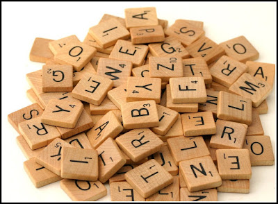

## To do…

- **PA 5.1: Scrambled Message**
  - Due Wednesday at 10:00am
- **LA 5: Murder in SQL City**
  - Due Saturday at 11:59 pm
- Look out for project and exam information posted on Canvas - we will discuss both on Wednesday